# Análise da precisão

```r
library(tidyverse)
library(here)
library(modelr)
library(broom)
theme_set(theme_bw())
```

O governo recebe um grande número de reclamações e poderia gerenciar melhor seus recursos se soubesse o quão insatisfeitas as pessoas estão em relação a um certo órgão. Existem métodos para análise de sentimento aplicáveis, mas não sabemos se esses métodos são eficazes neste contexto.

## Pergunta

**Quão eficazes são métodos de análise de sentimento baseados em léxicos para estimar a insatisfação manifestada em reclamações recebidas pelo governo federal?**

## Resumo da nossa abordagem

Para analisar a eficiência de léxicos em determinar insatisfação de uma reclamação do https://www.reclameaqui.com.br em relação ao Governo federal, comparamos o resultado dos mesmos com a avaliação de insatisfação dada por seres humanos.

### EDA

Realizamos uma EDA básica que pode ser vista ao longo dos notebooks, buscando responder perguntas como: quantas palavras os léxicos conseguem de fato identificar nas reclamações?

### Calculando a insatisfação

Para calcular a insatisfação pelo léxico tentamos várias abordagens:

1. Somatório simples das palavras identificadas pelo léxico.
2. Somatório ponderado sendo palavras que são adjetivos consideradas mais importantes (peso 2 vezes maior).
3. Somatório simples / número de palavras identificadas pelo léxico.
4. Somatório ponderado / número de palavras identificadas pelo léxico.

A implementação dessas abordagens e alguns outros tratamentos foram feitos no arquivo calcula-sentimentos.Rmd que pode ser acessado no nosso repositório git: https://github.com/mari-linhares/reclamacoes-do-gf.

Como nesta análise não obtivemos grandes diferenças, mantivemos apenas a abordagem 1 e omitimos os resultados das demais análises para simplificação (porém essas podem ser obtidas no repositório git).

### Normalizando a saída dos léxicos

Para comparar os resultados dos léxicos, que consistia de números positivos e negativos, com a nota de insatisfação dada por pessoas, que estava numa escala entre 0 e 5, precisamos normalizar os dados dos léxicos. Para tal, utilizamos duas abordagens:

1. Fazer com que o menor resultado obtido de um léxico equivalesse a 5 e o maior a 0, com os valores intermediários seguindo a mesma proporção
2. Fazer com que o primeiro quartil e os valores abaixo dele equivalessem a 5, o terceiro quartil e os valores acima dele equivalessem a 0, com os valores intermediários seguindo a mesma proporção.

A primeira abordagem se mostrou mais coerente então a maior parte das análises foi feita com ela.

### Regressão

Após conferir e entender alguns dados sobre a resposta dos léxicos, calculamos os erros de cada combinação de léxico e forma de normalizar. Com este erro, geramos regressões lineares com:

- Erro ← Léxico
- Erro ← Léxico + N° Palavras
- Erro ← Léxico + N° Palavras + Órgão
- Erro ← N° Palavras + N° Adjetivos + Nº de palavras conhecidas pelo léxico (uma regressão para cada léxico)

### Conclusão

Ao final, conseguimos observar que o léxico não parece influenciar no erro, mas em alguns modelos o número de palavras que uma reclamação possui e alguns órgãos parecem ter uma certa relação (embora o número de palavras tenha um efeito pouco relevante).

Utilizando uma definição de acerto para os léxicos de que o léxico acertou se o erro foi menor que 1, obtivemos um acerto de 61% para o léxico sent e 58% para o léxico op30.

## Carregando os dados

```r
reclamacoes_raw = read_csv(here("data/reclamacoes-raw/reclamacoes-raw.csv"))
avaliacoes_raw = read_csv(here("data/avaliacoes/avaliacoes-20180222.csv"))
sentimentos = read_csv(here("data/sentimentos/sentimento.csv"))
```

```r
# sentimentos_ponderados = read_csv(here("data/sentimentos/sentimento_ponderado.csv"))

# adicionando id a reclamacoes, comprimento da reclamacao e nome do orgao
reclamacoes_raw = reclamacoes_raw %>%
    mutate(id = 1:n(),
           comprimento_reclamacao = str_length(reclamacao),
           nome_orgao = str_split(link, "/") %>% map_chr(~ .[[5]]))
```

`reclamacoes_l` tem um formato long em vez de wide (explicado [aqui](https://sejdemyr.github.io/r-tutorials/basics/wide-and-long/)).

```r
avaliacoes = avaliacoes_raw %>%
    group_by(id_reclamação) %>%
    summarise(insatisfação = median(insatisfação),
              avaliadores = n())

reclamacoes = reclamacoes_raw %>%
    inner_join(avaliacoes, by = c("id" = "id_reclamação")) %>%
    left_join(sentimentos, by = "id")

reclamacoes_l = reclamacoes %>%
    # select(-palavras_op30, -palavras_sent) %>%
    gather(key = "lexico",
           value = "polaridade",
           sentimento_op30, sentimento_sent)
```

Removendo reclamações em que pelo menos um dos léxicos não reconhece nenhuma palavra.

```r
reclamacoes_l = subset(reclamacoes_l, palavras_op30>0 & palavras_sent>0)
reclamacoes = subset(reclamacoes, palavras_op30>0 & palavras_sent>0)
```

## Converte polaridades para escala 0-5

Antes de converter é importante saber alguns valores chaves para cada léxico, como o mínimo, máximo e os quartis.

```r
summary(reclamacoes)
```

```
##     orgao               link              titulo
##  Length:155         Length:155         Length:155
##  Class :character   Class :character   Class :character
##  Mode  :character   Mode  :character   Mode  :character
##
##
##
##   reclamacao              id        comprimento_reclamacao
##  Length:155         Min.   :  2.0   Min.   : 111
##  Class :character   1st Qu.: 50.5   1st Qu.: 434
##  Mode  :character   Median :127.0   Median : 635
##                     Mean   :133.9   Mean   :1064
##                     3rd Qu.:205.5   3rd Qu.:1228
##                     Max.   :318.0   Max.   :9598
##   nome_orgao         insatisfação    avaliadores    sentimento_op30
##  Length:155         Min.   :0.750   Min.   :1.000   Min.   :-17.0
##  Class :character   1st Qu.:2.000   1st Qu.:1.000   1st Qu.: -1.0
##  Mode  :character   Median :3.000   Median :1.000   Median :  1.0
##                     Mean   :2.876   Mean   :1.594   Mean   :  1.2
##                     3rd Qu.:4.000   3rd Qu.:2.000   3rd Qu.:  3.0
##                     Max.   :5.000   Max.   :5.000   Max.   : 28.0
##  palavras_op30    sentimento_sent    palavras_sent       palavras
##  Min.   :  1.00   Min.   :-16.0000   Min.   : 1.000   Min.   :  16.0
##  1st Qu.:  7.00   1st Qu.: -1.5000   1st Qu.: 2.000   1st Qu.:  68.5
##  Median : 13.00   Median :  0.0000   Median : 3.000   Median : 106.0
##  Mean   : 21.71   Mean   : -0.1226   Mean   : 4.735   Mean   : 176.6
##  3rd Qu.: 25.50   3rd Qu.:  1.0000   3rd Qu.: 5.000   3rd Qu.: 200.5
##  Max.   :190.00   Max.   : 18.0000   Max.   :45.000   Max.   :1593.0
##  quant_adj_op30   quant_adj_sent
##  Min.   :  0.00   Min.   : 0.000
##  1st Qu.:  5.00   1st Qu.: 1.000
##  Median :  8.00   Median : 2.000
##  Mean   : 14.41   Mean   : 3.168
##  3rd Qu.: 17.00   3rd Qu.: 4.000
##  Max.   :135.00   Max.   :32.000
```

```r
min_op30 = min(reclamacoes$sentimento_op30)
max_op30 = max(reclamacoes$sentimento_op30)
first_quantile_op30 = quantile(reclamacoes$sentimento_op30, 0.25, na.rm=T)
third_quantile_op30 = quantile(reclamacoes$sentimento_op30, 0.75, na.rm=T)

min_sent = min(reclamacoes$sentimento_sent)
max_sent = max(reclamacoes$sentimento_sent)
first_quantile_sent = quantile(reclamacoes$sentimento_sent, 0.25, na.rm=T)
third_quantile_sent = quantile(reclamacoes$sentimento_sent, 0.75, na.rm=T)
```

### Normalizando da maneira usual entre 0 e 5.

Agora iremos calcular a polaridade_normalizada_usal usando a estratégia mais simples, normalizando os valores entre 0 e 5 de maneira usual.

```r
 polarizeResultUsual <- function(Min, Max){
     range = Max - Min
     arr = (reclamacoes_l$polaridade - Min)/range
     normalized = 5 - ((arr*5) -0)  # invertendo 0-> 5 e 5->0
     return(normalized)
 }

# reclamacoes long
reclamacoes_l$polaridade_normalizada_usual <-        ifelse(reclamacoes_l$lexico=="sentimento_op30", polarizeResultUsual(min_op30, max_op30), polarizeResultUsual(min_sent, max_sent))

# reclamacoes op30
polarizeResultUsual2 <- function(Min, Max){
     range = Max - Min
     arr = (reclamacoes$sentimento_op30 - Min)/range
     normalized = 5 - ((arr*5) -0)  # invertendo 0-> 5 e 5->0
     return(normalized)
 }
reclamacoes$sentimento_op30_usual <- polarizeResultUsual2(min_op30, max_op30)

# reclamacoes sent
polarizeResultUsual3 <- function(Min, Max){
     range = Max - Min
     arr = (reclamacoes$sentimento_sent - Min)/range
     normalized = 5 - ((arr*5) -0)  # invertendo 0-> 5 e 5->0
     return(normalized)
 }
reclamacoes$sentimento_sent_usual <- polarizeResultUsual3(min_sent, max_sent)
```

### Normalizando utilizando os quartis

Como os resultados dos léxicos possuem muitos valores extremos, criaremos a polaridade_normalizada_quartil que ao invés de considerar os mínimos e máximos, considera os primeiros e terceiros quartis.

```r
polarizeResultQuartil <- function(Min, Max){
     range = Max - Min
     arr = (reclamacoes_l$polaridade - Min)/range
     normalized = 5 - ((arr*5) -0)
     normalized <- ifelse(arr<0, 5, normalized)
     normalized <- ifelse(arr>1, 0, normalized)
     return(normalized)
 }

# reclamacoes long
reclamacoes_l$polaridade_normalizada_quartil <- ifelse(reclamacoes_l$lexico=="sentimento_op30", polarizeResultQuartil(first_quantile_op30, third_quantile_op30), polarizeResultQuartil(first_quantile_sent, third_quantile_sent))

# reclamacoes op30
polarizeResultQuartil2 <- function(Min, Max){
     range = Max - Min
     arr = (reclamacoes$sentimento_op30 - Min)/range
     normalized = 5 - ((arr*5) -0)
     normalized <- ifelse(arr<0, 5, normalized)
     normalized <- ifelse(arr>1, 0, normalized)
     return(normalized)
 }

reclamacoes$sentimento_op30_quartil <- polarizeResultQuartil2(first_quantile_op30, third_quantile_op30)

# reclamacoes sent
polarizeResultQuartil3 <- function(Min, Max){
     range = Max - Min
     arr = (reclamacoes$sentimento_sent - Min)/range
     normalized = 5 - ((arr*5) -0)
     normalized <- ifelse(arr<0, 5, normalized)
     normalized <- ifelse(arr>1, 0, normalized)
     return(normalized)
 }

reclamacoes$sentimento_sent_quartil <- polarizeResultQuartil3(first_quantile_sent, third_quantile_sent)
```

## Calculando o erro por reclamação

```r
reclamacoes_l = reclamacoes_l %>%
    mutate(erro_usual = (insatisfação - polaridade_normalizada_usual)**2,
           erro_quartil = (insatisfação - polaridade_normalizada_quartil)**2)
```

## EDA - Verificando os resultados

### Comparando os valores dos léxicos

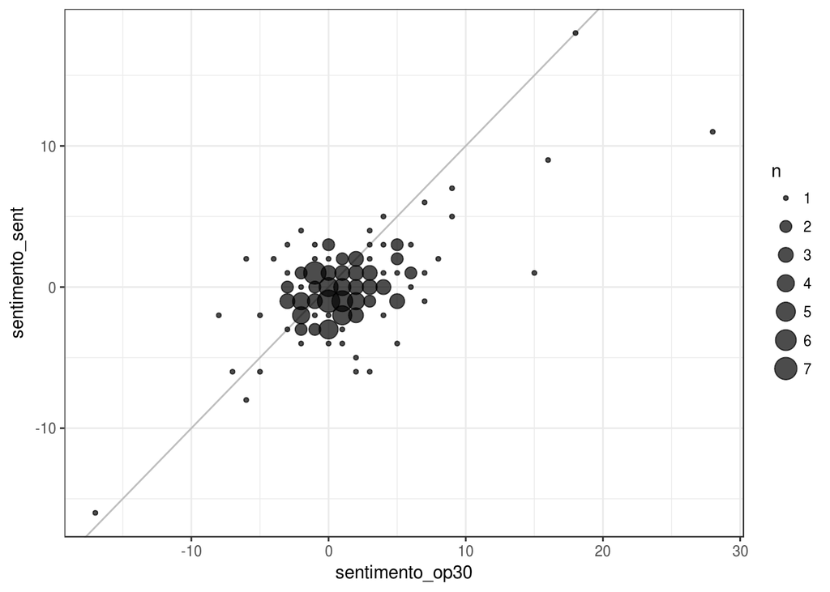

```r
reclamacoes %>%
    ggplot(aes(x = sentimento_op30, y = sentimento_sent)) +
    geom_abline(slope = 1, intercept = 0, color = "grey") +
    geom_count(alpha = .7)
```

### Comparando os valores dos léxicos normalizados

#### Normalização usual

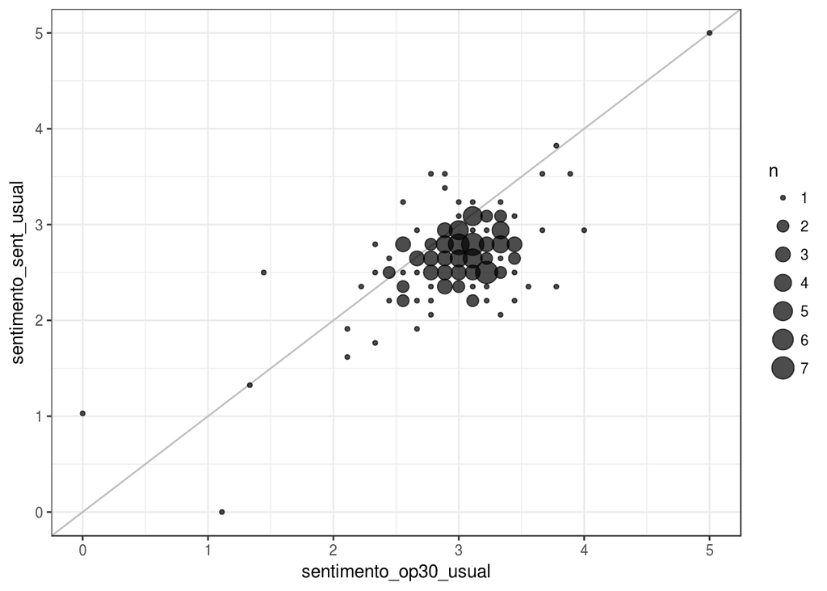

```r
reclamacoes %>%
    ggplot(aes(x = sentimento_op30_usual, y = sentimento_sent_usual)) +
    geom_abline(slope = 1, intercept = 0, color = "grey") +
    geom_count(alpha = .7)
```

### Normalização utilizando os quartis

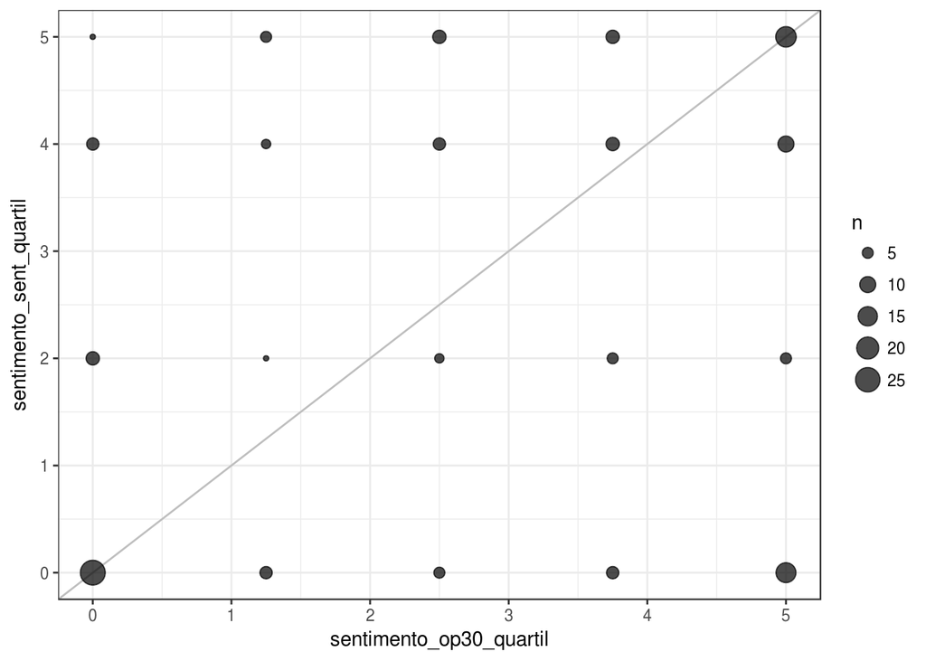

```r
reclamacoes %>%
    ggplot(aes(x = sentimento_op30_quartil, y = sentimento_sent_quartil)) +
    geom_abline(slope = 1, intercept = 0, color = "grey") +
    geom_count(alpha = .7)
```

### Erro e comparação das normalizações

### Usual

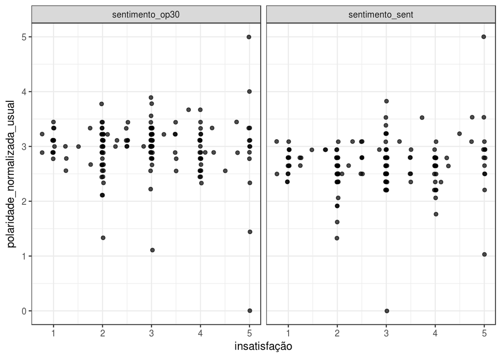

```r
reclamacoes_l %>%
    ggplot(aes(x = insatisfação, y = polaridade_normalizada_usual, group = insatisfação)) +
    geom_jitter(alpha = .7)  +
    facet_wrap(~ lexico)
```

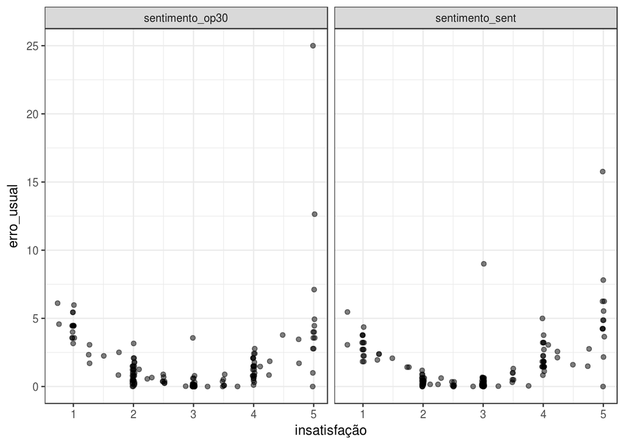

```r
reclamacoes_l %>%
    ggplot(aes(x = insatisfação, y = erro_usual, group = insatisfação)) +
    geom_jitter(alpha = .5)  +
    # geom_boxplo() +
    facet_wrap(~ lexico)
```

### Quartil

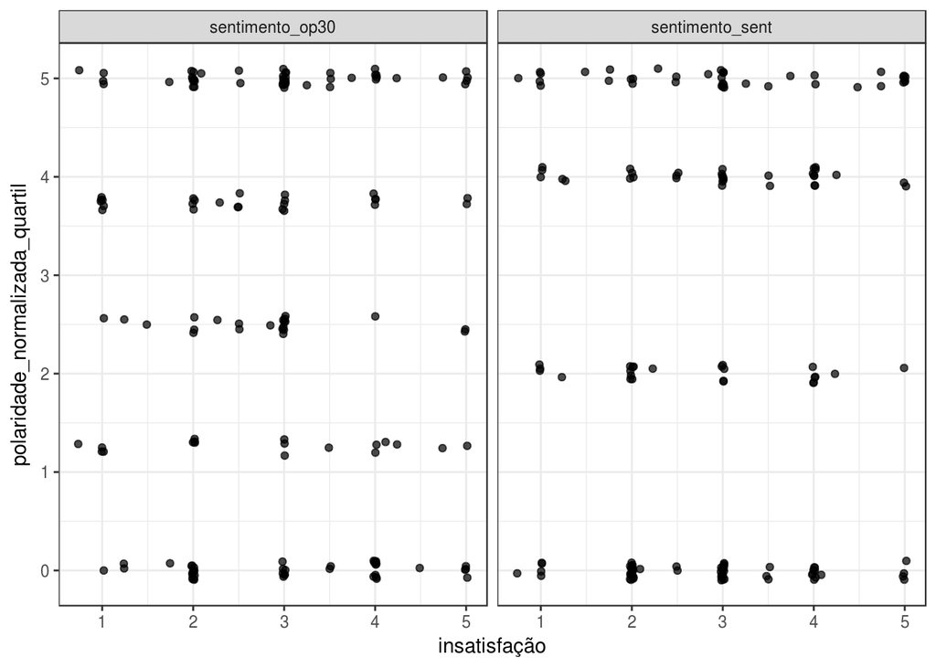

```r
reclamacoes_l %>%
    ggplot(aes(x = insatisfação, y = polaridade_normalizada_quartil, group = insatisfação)) +
    geom_jitter(alpha = .7)  +
    facet_wrap(~ lexico)
```

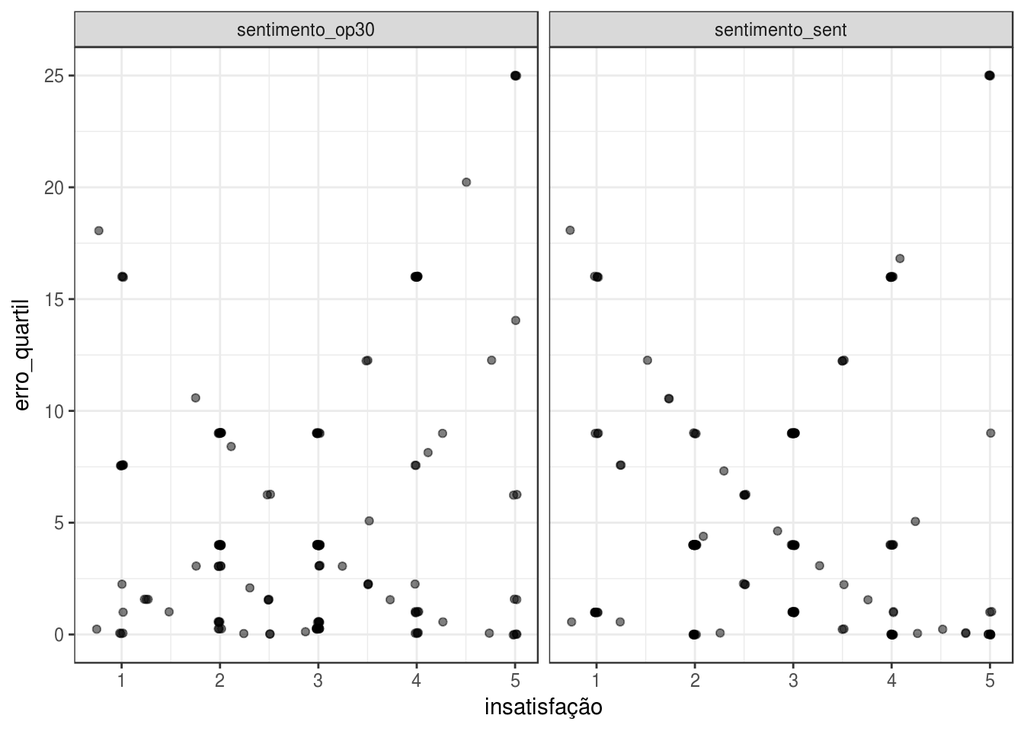

```r
reclamacoes_l %>%
    ggplot(aes(x = insatisfação, y = erro_quartil, group = insatisfação)) +
    geom_jitter(alpha = .5)  +
    # geom_boxplo() +
    facet_wrap(~ lexico)
```

## Há relação entre o léxico e a precisão/erro?

Aqui iremos construir vários modelos buscando entender a relação entre o léxico (e outras variáveis independentes) e o erro.

### Considerando apenas o léxico

```r
model_erro_lex = lm(erro_usual ~ factor(lexico), data=reclamacoes_l)
tidy(model_erro_lex, conf.int = TRUE, conf.level = 0.95)
```

| term | estimate | std.error | statistic | p.value | conf.low | conf.high |
| --- | --- | --- | --- | --- | --- | --- |
| (Intercept) | 1.6207533 | 0.1893212 | 8.5608656 | 5.413439e-16 | 1.248227 | 1.9932798 |
| factor(lexico)sentimento_sent | -0.1379669 | 0.2677406 | -0.5153005 | 6.067127e-01 | -0.664799 | 0.3888652 |

```r
glance(model_erro_lex)
```

| r.squared | adj.r.squared | sigma | statistic | p.value | df | logLik | AIC | BIC | deviance | df.residual |
| --- | --- | --- | --- | --- | --- | --- | --- | --- | --- | --- |
| 0.0008613828 | -0.002382574 | 2.35703 | 0.2655346 | 0.6067127 | 2 | -704.6624 | 1415.325 | 1426.535 | 1711.122 | 308 |

Regressão simples foi utilizada para analisar se o léxico tem uma associação significativa com o erro na estimativa de instatisfação da reclamação. Os resultados da regressão indicam que um modelo com os preditores no formato Erro = X1.léxico explicam basicamente nada da variância da variável de resposta (R² = 0.0008613828).

- léxico: medida como fator (0 ou 1) tem uma relação não significativa com o erro (b = [-0.664799; 0.3888652], IC com 95%). Não podemos afirmar se um léxico é “melhor” que o outro para estes dados usando este modelo.

Pelos resultados do p.value, cujo alpha está bem acima de 0.05, e do intervalo de confiança, que inclue 0, não parece haver relação entre o léxico e o erro.

### Considerando o léxico e o número de palavras

```r
model_erro_lex = lm(erro_usual ~ factor(lexico) + palavras, data=reclamacoes_l)
tidy(model_erro_lex, conf.int = TRUE, conf.level = 0.95)
```

| term | estimate | std.error | statistic | p.value | conf.low | conf.high |
| --- | --- | --- | --- | --- | --- | --- |
| (Intercept) | 0.786057859 | 0.1999133241 | 3.9319933 | 1.041789e-04 | 0.392684156 | 1.179431563 |
| factor(lexico)sentimento_sent | -0.137966870 | 0.2430387936 | -0.5676743 | 5.706711e-01 | -0.616199478 | 0.340265738 |
| palavras | 0.004726129 | 0.0005782945 | 8.1725302 | 7.999898e-15 | 0.003588207 | 0.005864052 |

```r
glance(model_erro_lex)
```

| r.squared | adj.r.squared | sigma | statistic | p.value | df | logLik | AIC | BIC | deviance | df.residual |
| --- | --- | --- | --- | --- | --- | --- | --- | --- | --- | --- |
| 0.1793912 | 0.1740453 | 2.13957 | 33.55625 | 6.605401e-14 | 3 | -674.1511 | 1356.302 | 1371.249 | 1405.372 | 307 |

Regressão múltipla foi utilizada para analisar se o léxico e o número de palavras têm uma associação significativa com o erro na estimativa de instatisfação da reclamação. Os resultados da regressão indicam que um modelo com os preditores no formato Erro = X1.léxico + X2.palavras explicam ~18% da variância da variável de resposta (R² = 0.1793).

- léxico: medida como fator (0 ou 1) tem uma relação não significativa com o erro (b = [-0.616199478 0.340265738], IC com 95%). Não podemos afirmar se um léxico é “melhor” que o outro para estes dados usando este modelo.
- palavras: medida como unidade tem uma relação significativa com o erro (b = [0.003588207; 0.005864052], IC com 95%). Adicionar mais uma palavra ao texto faz com que o erro cresça ligeiramente, mais especificamente cerca de 0.005.

### Considerando o léxico, o número de palavras e o órgão

```r
model_erro_lex = lm(erro_usual ~ factor(lexico) + palavras + factor(nome_orgao), data=reclamacoes_l)
tidy(model_erro_lex, conf.int = TRUE, conf.level = 0.95)
```

| term | estimate | std.error | statistic | p.value | conf.low | conf.high |
| --- | --- | --- | --- | --- | --- | --- |
| (Intercept) | -0.216692531 | 0.6719851256 | -0.32246626 | 7.473303e-01 | -1.539240842 | 1.105855780 |
| factor(lexico)sentimento_sent | -0.137966870 | 0.2360364108 | -0.58451520 | 5.593251e-01 | -0.602515183 | 0.326581443 |
| palavras | 0.004851295 | 0.0006367796 | 7.61848337 | 3.600895e-13 | 0.003598035 | 0.006104555 |
| factor(nome_orgao)anac-agencia-nacional-de-aviacao-civil | -0.052107988 | 0.8910573509 | -0.05847883 | 9.534072e-01 | -1.805817036 | 1.701601059 |
| factor(nome_orgao)anp-agencia-nacional-do-petroleo-gas-natural-e-biocombustiv | 0.615065207 | 0.8047770685 | 0.76426781 | 4.453248e-01 | -0.968833769 | 2.198964183 |
| factor(nome_orgao)anvisa-agencia-nacional-de-vigilancia-sanitaria | 1.228592575 | 0.7927576887 | 1.54977062 | 1.222797e-01 | -0.331650802 | 2.788835953 |
| factor(nome_orgao)inss-ministerio-da-previdencia-social | 1.864671111 | 0.8195717452 | 2.27517740 | 2.362003e-02 | 0.251654415 | 3.477687808 |
| factor(nome_orgao)ministerio-da-cultura | 0.493875977 | 0.7660949889 | 0.64466676 | 5.196493e-01 | -1.013891970 | 2.001643925 |
| factor(nome_orgao)ministerio-da-fazenda | 0.711558872 | 0.9857241498 | 0.72186410 | 4.709557e-01 | -1.228465929 | 2.651583673 |
| factor(nome_orgao)ministerio-da-previdencia-social | 0.693356261 | 0.8051254141 | 0.86117796 | 3.898466e-01 | -0.891228301 | 2.277940824 |

[output cut: 8 more lines]

```r
glance(model_erro_lex)
```

| r.squared | adj.r.squared | sigma | statistic | p.value | df | logLik | AIC | BIC | deviance | df.residual |
| --- | --- | --- | --- | --- | --- | --- | --- | --- | --- | --- |
| 0.2638142 | 0.2209541 | 2.077925 | 6.155236 | 3.045146e-12 | 18 | -657.3237 | 1352.647 | 1423.642 | 1260.789 | 292 |

Regressão múltipla foi utilizada para analisar se o léxico, o número de palavras e o órgão têm uma associação significativa com o erro na estimativa de instatisfação da reclamação. Os resultados da regressão indicam que um modelo com os preditores no formato Erro = X1.léxico + X2.palavras + X3.órgão1 + X4.órgão2 + … + XN.órgãoN explicam ~26% da variância da variável de resposta (R² = 0.2638).

### Considerando o número de palavras, quantidade de palavras conhecidas pelo léxico e quantidade de adjetivos nas reclamações

Para está regressão iremos considerar cada léxico separadamente a fim de estudar os efeitos do número de palavras (palavras), quantidade de palavras conhecidas pelo léxico na reclamação (palavras_) e quantidade de adjetivos nas reclamações de acordo com os léxicos (quant_adj_).

#### Léxico op30

```r
lexico_op30 = filter(reclamacoes_l, lexico=="sentimento_op30")
model_erro_lex_adj_op30 = lm(erro_usual ~ quant_adj_op30 + palavras + palavras_op30, data=lexico_op30)
tidy(model_erro_lex_adj_op30, conf.int=T, conf.level=0.95)
```

| term | estimate | std.error | statistic | p.value | conf.low | conf.high |
| --- | --- | --- | --- | --- | --- | --- |
| (Intercept) | 0.5551325539 | 0.249607421 | 2.224022638 | 0.02763098 | 0.061958481 | 1.04830663 |
| quant_adj_op30 | -0.0674170880 | 0.069675974 | -0.967580126 | 0.33480129 | -0.205082803 | 0.07024863 |
| palavras | 0.0115819322 | 0.003881013 | 2.984254937 | 0.00331658 | 0.003913831 | 0.01925003 |
| palavras_op30 | -0.0003987588 | 0.057173352 | -0.006974557 | 0.99444436 | -0.113361807 | 0.11256429 |

```r
glance(model_erro_lex_adj_op30)
```

| r.squared | adj.r.squared | sigma | statistic | p.value | df | logLik | AIC | BIC | deviance | df.residual |
| --- | --- | --- | --- | --- | --- | --- | --- | --- | --- | --- |
| 0.2248284 | 0.2094276 | 2.340775 | 14.59852 | 2.130679e-08 | 4 | -349.7339 | 709.4678 | 724.6849 | 827.3631 | 151 |

O resultado explica ~22% da variância da variável de resposta (R²=0.2248284).

- quant_adj_op30: medida como unidade; tem uma relação não significativa com o erro (b = [-0.205082803; 0.07024863], IC com 95%).
- palavras: medida como unidade; tem uma relação significativa positiva com o erro (b = [0.003913831; 0.01925003], IC com 95%). De acordo com o modelo a cada palavra adicionada o erro aumenta ~0.012.
- palavras_op30: medida como unidade; tem uma relação não significativa com o erro (b = [-0.113361807; 0.11256429], IC com 95%).

#### Léxico sent

```r
lexico_sent = filter(reclamacoes_l, lexico=="sentimento_sent")
model_erro_lex_adj_sent = lm(erro_usual ~  quant_adj_sent + palavras + palavras_sent, data=lexico_sent)
tidy(model_erro_lex_adj_sent, conf.int=T, conf.level=0.95)
```

| term | estimate | std.error | statistic | p.value | conf.low | conf.high |
| --- | --- | --- | --- | --- | --- | --- |
| (Intercept) | 0.878088027 | 0.196725966 | 4.463509 | 0.0000156831 | 0.489397075 | 1.266778978 |
| quant_adj_sent | 0.318556109 | 0.105480110 | 3.020059 | 0.0029684222 | 0.110148620 | 0.526963598 |
| palavras | 0.003144787 | 0.001502112 | 2.093576 | 0.0379691292 | 0.000176915 | 0.006112659 |
| palavras_sent | -0.202685746 | 0.089772133 | -2.257780 | 0.0253929195 | -0.380057430 | -0.025314061 |

```r
glance(model_erro_lex_adj_sent)
```

| r.squared | adj.r.squared | sigma | statistic | p.value | df | logLik | AIC | BIC | deviance | df.residual |
| --- | --- | --- | --- | --- | --- | --- | --- | --- | --- | --- |
| 0.1994397 | 0.1835345 | 1.847488 | 12.5393 | 2.294634e-07 | 4 | -313.0524 | 636.1047 | 651.3219 | 515.3949 | 151 |

O resultado explica ~19% da variância da variável de resposta (R²=0.1994397).

- quant_adj_sent: diferentemente dos resultados do léxico op30, a quantidade de adjetivos tem uma relação significativa positiva com o erro (b = [0.110148620; 0.526963598], IC com 95%). Temos que a cada adjetivo a mais na reclamação o valor do erro deve aumentar por volta de ~0.31.
- palavras: medida como unidade; tem uma relação significativa positiva com o erro (b = [0.000176915; 0.006112659], IC com 95%). De acordo com o modelo a cada palavra adicionada o erro aumenta ~0.003.
- palavras_sent: medida como unidade; tem uma relação significativa negativa com o erro (b = [-0.380057430; -0.025314061], IC com 95%). Esse resultado é interessante pois indica que se adicionarmos uma palavra conhecida (do léxico) a reclamação o erro tende a diminuir em ~0.2 unidades.

# Podemos Utilizar os léxicos para avaliar insatisfação humana em uma reclamação?

Para responder tal pergunta, definimos que um léxico “acerta” o nível de insatisfação quando seu erro é igual ou menor que 1. Com isso, calculamos a porcentagem de acerto de cada léxico com forma de normalização.

```r
total_op30 = reclamacoes_l %>%
    filter(lexico == "sentimento_op30") %>%
    count()
hits_usual_op30 = reclamacoes_l %>%
    filter(lexico == "sentimento_op30") %>%
    filter(erro_usual <= 1) %>%
    count()
hits_quart_op30 = reclamacoes_l %>%
    filter(lexico == "sentimento_op30") %>%
    filter(erro_quartil <= 1) %>%
    count()

total_sent = reclamacoes_l %>%
    filter(lexico == "sentimento_sent") %>%
    count()
hits_usual_sent = reclamacoes_l %>%
    filter(lexico == "sentimento_sent") %>%
    filter(erro_usual <= 1) %>%
    count()
hits_quart_sent = reclamacoes_l %>%
    filter(lexico == "sentimento_sent") %>%
    filter(erro_quartil <= 1) %>%
    count()

sprintf("Porcentagem de hits OP30 (Usual): %f", hits_usual_op30/total_op30)
```

```
## [1] "Porcentagem de hits OP30 (Usual): 0.580645"
```

```r
sprintf("Porcentagem de hits OP30 (Quartil): %f", hits_quart_op30/total_op30)
```

```
## [1] "Porcentagem de hits OP30 (Quartil): 0.296774"
```

```r
sprintf("Porcentagem de hits Sent (Usual): %f", hits_usual_sent/total_sent)
```

```
## [1] "Porcentagem de hits Sent (Usual): 0.580645"
```

```r
sprintf("Porcentagem de hits Sent (Quartil): %f", hits_quart_sent/total_sent)
```

```
## [1] "Porcentagem de hits Sent (Quartil): 0.348387"
```

Com tais resultados concluímos duas coisas: A primeira que a utilização da normalização usual foi bem melhor que as dos quartis para os nossos dados. A segunda coisa foi que o léxico acerta o nível de insatisfação em cerca de 60% das reclamações, acertando cerca de 3 a cada 5 reclamações.

> obs: por algum motivo no knit hits sent = hits op30, porem rodando localmente vimos que hits sent = 0.610687. Devido ao tempo não conseguimos investigar a fundo o motivo da diferença.

### Porcentagem de palavras identificadas pelos léxicos

No gráfico abaixo verificamos um histograma da porcentagem de palavras identificadas pelos léxicos.

#### Lexico sent

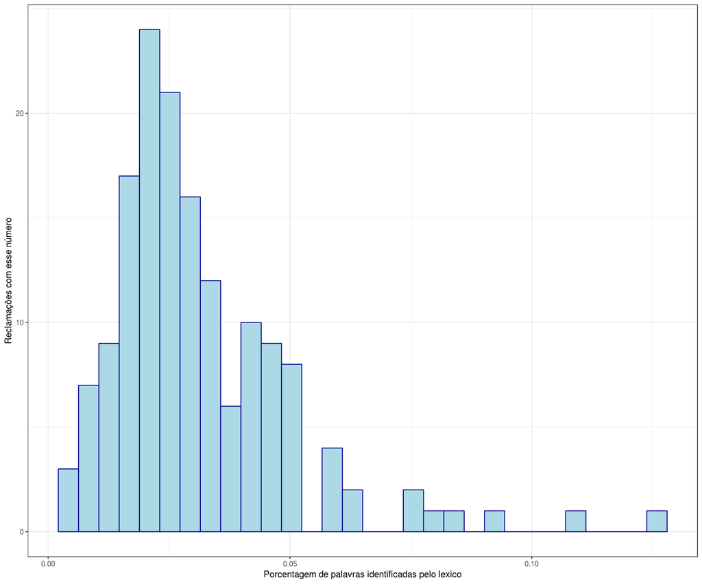

```r
ggplot(data=lexico_op30, aes(lexico_sent$palavras_sent/palavras)) +
  geom_histogram(bins = 30, color="darkblue", fill="lightblue") +
  labs(x="Porcentagem de palavras identificadas pelo lexico", y="Reclamações com esse número") + scale_y_continuous(breaks=seq(0, 250, 10)) +
  scale_x_continuous(breaks=seq(0, 0.5, 0.05))
```

#### Lexico op30

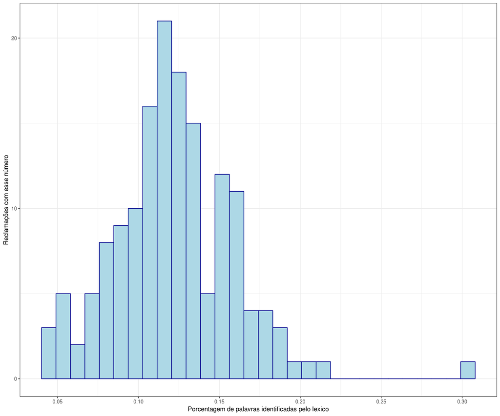

```r
ggplot(data=lexico_sent, aes(lexico_op30$palavras_op30/palavras)) +
  geom_histogram(bins = 30, color="darkblue", fill="lightblue") +
  labs(x="Porcentagem de palavras identificadas pelo lexico", y="Reclamações com esse número") + scale_y_continuous(breaks=seq(0, 250, 10)) +
  scale_x_continuous(breaks=seq(0, 0.5, 0.05))
```